# Homework 7: Loops and Functions

KEY

Due: 11/17

# 1. For and While Loops

### Question 1.1: Write in words the difference between a `for` loop and a `while` loop.

> ANSWER: Both for and while loops allow for applying code iteratively. A for loop runs through a pre-specified set of indices, but a while loop runs until some condition is met.

### Question 1.2: Create a matrix with 3 rows and 8 columns, called `double_matrix`. Make the first column equal to the values 1, 2, and 3. Using a loop, fill in the matrix, row by row, such that each value is double that to its left.

For example, the first row of the matrix should be: 1, 2, 4, 8, 16, 32, 64, 128

```r
double_matrix <- matrix(NA,nrow=3,ncol=8)
double_matrix[,1] <- 1:3
for(row in 1:3){
  for(col in 2:8){
    double_matrix[row,col] <- 2 * double_matrix[row,col-1]
  }
}
print(double_matrix)
```

```
##      [,1] [,2] [,3] [,4] [,5] [,6] [,7] [,8]
## [1,]    1    2    4    8   16   32   64  128
## [2,]    2    4    8   16   32   64  128  256
## [3,]    3    6   12   24   48   96  192  384
```

### Question 1.3: Write a while loop that keeps “flipping 5 coins” until all are heads. Have the function count how many sets of 5 coin flips it took until getting 5 heads, and return that number.

*Hint:* You can flip 5 coins using the code `rbinom(n=5,size=1,prob=.5)`. A heads is when you return a `1`.

```r
num_heads <- 0
counter <- 0
while(num_heads < 5){
  coins <- rbinom(n=5,size=1,prob=.5)
  num_heads <- sum(coins)
  counter <- counter + 1
}
print(counter)
```

```
## [1] 24
```

**Note:** Due to the randomness of the `rbinom` function, each person may have a different output number!

# 2. Functions

### Question 2.1: Pick a built-in R function and describe its input(s) and output(s).

> ANSWER: The function `summary` takes an object as an input, such as a number, vector, matrix, or data.frame. It then outputs a summary of the object as best its able. Oftentimes, it will summarize matrices or data.frames by column. Output often includes the min, first quartile, median, mean, third quartile, and max.

### Question 2.2: Write a function, called `doubler`, that takes a single number as its input and returns a vector of length 8. The vector should contain the initial value, doubled consecutive times. Be sure to check if a single number was given!

*Hint:* If input is 1, output should be `c(1,2,4,8,16,32,64,128)`.

```r
doubler <- function(x){
  ## Solution 1:
  vals <- c(x)
  for(i in 1:7){
    x <- x*2
    vals <- c(vals,x)
  }
  return(vals)

  ## Solution 2:
  # vals <- c(x,x*2,x*4,x*8,x*16,x*32,x*64,x*128)
  # return(vals)

  ## Solution 3:
  # vals <- x*2^(0:7)
  # return(vals)
}
```

### Question 2.3: Use `doubler` on the inputs 1, 2, and 3. Do you get the same values as in question 1.2? (You should!)

```r
doubler(1)
```

```
## [1]   1   2   4   8  16  32  64 128
```

```r
doubler(2)
```

```
## [1]   2   4   8  16  32  64 128 256
```

```r
doubler(3)
```

```
## [1]   3   6  12  24  48  96 192 384
```

# 3. Apply

### Question 3.1 What’s similar/different between a `for` loop and `apply`?

> ANSWER: `for` loops and `apply` can usually accomplish the same tasks: Each uses code iteratively.`for` loops are more flexible, in that you can provide different data using indices to the loop; they are harder to write. `apply` loops are simpler and don’t require preallocation; they require your data be a matrix or dataframe.

### Question 3.2 Write an `apply()` function to take the median value of each column in the `cars` dataset

```r
median_cars <- apply(cars,2,median)
median_cars
```

```
## speed  dist
##    15    36
```

### Question 3.3 Using `ggplot`, make a scatterplot of the `speed` and `dist` variables in `cars`. Then, add an appropriate horizontal and vertical line symbolizing the median value of each variable.

*Hint:* Using the layers `geom_vline(xintercept = )` and `geom_hline(yintercept = )`

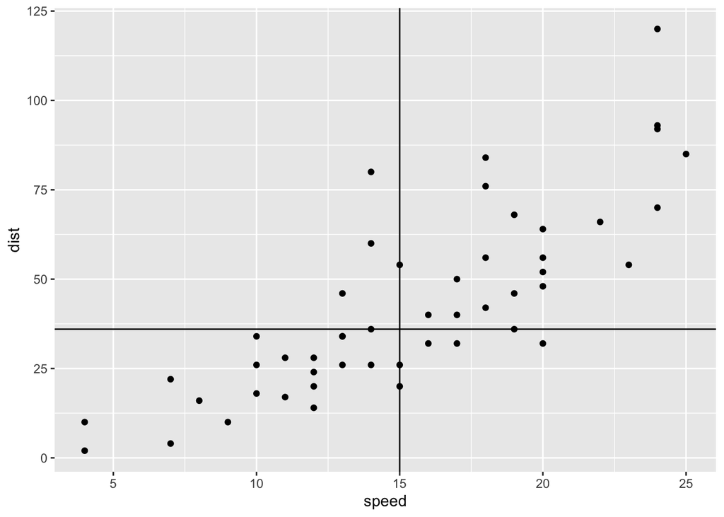

```r
library(ggplot2)
ggplot(cars,aes(speed,dist))+geom_point()+
  geom_vline(xintercept = median_cars[1])+
  geom_hline(yintercept = median_cars[2])
```

### Question 3.4: Repeat steps 3.2 and 3.3, but this time using a function you create called `half_max`. This function should return the maximum value of a vector divided by 2.

*Hint:* Given the vector `1:6`, `half_max` should return 3 (since 6/2 = 3).

```r
half_max <- function(vector){
  half_max <- max(vector)/2
  return(half_max)
}
halfmax_cars <- apply(cars,2,half_max)
halfmax_cars
```

```
## speed  dist
##  12.5  60.0
```

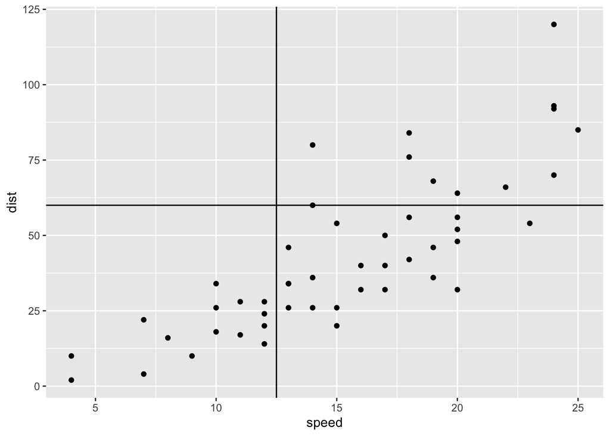

```r
ggplot(cars,aes(speed,dist))+geom_point()+
  geom_vline(xintercept = halfmax_cars[1])+
  geom_hline(yintercept = halfmax_cars[2])
```